### Part II

#### Solution

Tuesday, November 17, 2015

1. First, create a new variable $real\_sales = 100*sales\_b/price\_index$, this is the Real Sales after adjusting for price index. Plot Real GDP against Real Sales, make a sketch based on SAS/R output. What do the plot suggest (as far as using standard statistical methodology is concerned)?  
   **Solution**  
   First read in data and clean it.

```r
# File is csv.
# Cannot copy and paste into `R` script.
expenditure.df <- read.csv(file="http://algebra.sci.csueastbay.edu/~esuess/msexam/pastmsexam/2015/Fall%202015/Expenditure.csv", header=TRUE)

# `realgdp_b` is treated as factors, and some entries have commas.
# So remove commas:
expenditure.df$realgdp_b <- gsub(pattern=",", replacement="", x=expenditure.df$realgdp_b)

# `realgdp_b` is now a character variable
# convert `realgdp_b` from character to numeric
expenditure.df$realgdp_b <- as.numeric(expenditure.df$realgdp_b)
```

New variable `real_sales`

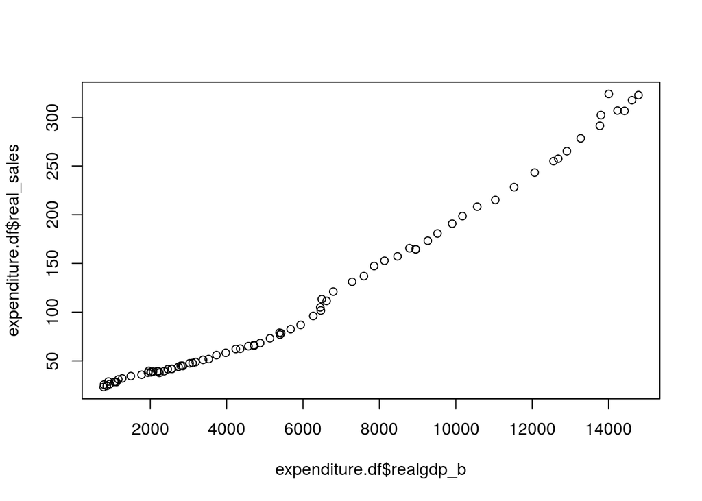

```r
expenditure.df$real_sales <- 100*expenditure.df$sales_b/expenditure.df$price_index

plot(x=expenditure.df$realgdp_b, y=expenditure.df$real_sales)
```

“The real sales increases as the real GDP increases. The association is a very positive one. The relationship however is not linear.”

“A second order `real_gdp` is created ($real\_gdp^2$) and was found to be significant.”

```r
gdp.sq.lm <- lm(formula=real_sales ~ realgdp_b + I(realgdp_b^2), data=expenditure.df)
summary(gdp.sq.lm)
```

```
##
## Call:
## lm(formula = real_sales ~ realgdp_b + I(realgdp_b^2), data = expenditure.df)
##
## Residuals:
##      Min       1Q   Median       3Q      Max
## -11.1515  -4.5507  -0.2676   4.0859  19.9332
##
## Coefficients:
##                 Estimate Std. Error t value Pr(>|t|)
## (Intercept)    1.546e+01  1.841e+00   8.398 1.74e-12 ***
## realgdp_b      8.458e-03  6.418e-04  13.178  < 2e-16 ***
## I(realgdp_b^2) 8.670e-07  4.235e-08  20.470  < 2e-16 ***
## ---
## Signif. codes:  0 '***' 0.001 '**' 0.01 '*' 0.05 '.' 0.1 ' ' 1
##
## Residual standard error: 5.961 on 77 degrees of freedom
## Multiple R-squared:  0.9959, Adjusted R-squared:  0.9958
## F-statistic:  9325 on 2 and 77 DF,  p-value: < 2.2e-16
```

2. Fit a simple linear regression using only the $year$ as explanatory variable, and $real\_sales$ as the response variable. Write down the fitted model and make interpretations of the estimates. What conclusion can you draw regarding whether average households have increased Clothing/Footwear expenditures over the last 80 years? Comment on the residual plot.  
   **Solution**

```r
simple.lm <- lm(formula=real_sales ~ year, data=expenditure.df)
summary(simple.lm)
```

```
##
## Call:
## lm(formula = real_sales ~ year, data = expenditure.df)
##
## Residuals:
##     Min      1Q  Median      3Q     Max
## -49.416 -32.637  -8.621  31.161  79.649
##
## Coefficients:
##               Estimate Std. Error t value Pr(>|t|)
## (Intercept) -7027.4081   350.6252  -20.04   <2e-16 ***
## year            3.6232     0.1779   20.36   <2e-16 ***
## ---
## Signif. codes:  0 '***' 0.001 '**' 0.01 '*' 0.05 '.' 0.1 ' ' 1
##
## Residual standard error: 36.75 on 78 degrees of freedom
## Multiple R-squared:  0.8417, Adjusted R-squared:  0.8396
## F-statistic: 414.7 on 1 and 78 DF,  p-value: < 2.2e-16
```

Model: $\widehat{real\_sales} = -7027 + 3.62 \cdot year$ “Interpretation: The intercept does not have a meaningful interpretation here because the year cannot be equal to 0.”

“For every one unit of increase in year, the real sales after adjusting for price index goes up by $3.62 billion on average.”

“Yes, the *p*-value is significant.”

“The residual plot has a curvature pattern indicating a lack of fit. A second order of year should be added to the model.”

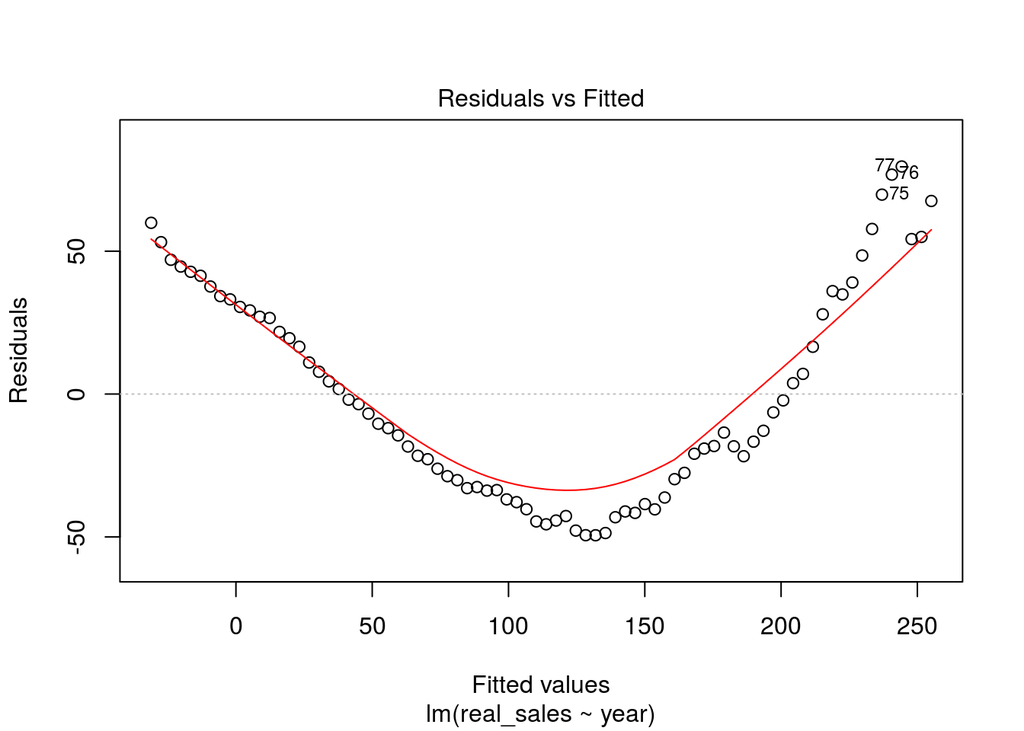

```r
plot(simple.lm, which=1)
```

3. Now consider multiple linear regression of $real\_sales$, with all other variables captured (first order additive model only). Use stepwise forward selection method to find the “best” sub-model ($\alpha\_\text{entry}=0.1, \alpha\_\text{stay}=0.1$). Write down your final fitted model and use it for (d) and (e).  
   **Solution**  
   I have yet to find a simple solution to stepwise regression using $\alpha$ values. The only feasible option (as far as I know) is to use this function (source: http://orinanobworld.blogspot.ca/2011/02/stepwise-regression-in-r.html):

```r
#
# This is an R function to perform stepwise regression based on a "nested model" F test for inclusion/exclusion
# of a predictor.  To keep it simple, I made no provision for forcing certain variables to be included in
# all models, did not allow for specification of a data frame, and skipped some consistency checks (such as whether
# the initial model is a subset of the full model).
#
# One other note: since the code uses R's drop1 and add1 functions, it respects hierarchy in models. That is,
# regardless of p values, it will not attempt to drop a term while retaining a higher order interaction
# involving that term, nor will it add an interaction term if the lower order components are not all present.
# (You can of course defeat this by putting interactions into new variables and feeding it what looks like
# a first-order model.)
#
# Consider this to be "beta" code (and feel free to improve it).  I've done very limited testing on it.
#
# Author: Paul A. Rubin (rubin@msu.edu)
#
stepwise <- function(full.model, initial.model, alpha.to.enter, alpha.to.leave) {
  # full.model is the model containing all possible terms
  # initial.model is the first model to consider
  # alpha.to.enter is the significance level above which a variable may enter the model
  # alpha.to.leave is the significance level below which a variable may be deleted from the model
  # (Useful things for someone to add: specification of a data frame; a list of variables that must be included)
  full <- lm(full.model);  # fit the full model
  msef <- (summary(full)$sigma)^2;  # MSE of full model
  n <- length(full$residuals);  # sample size
  allvars <- attr(full$terms, "predvars");  # this gets a list of all predictor variables
  current <- lm(initial.model);  # this is the current model
  while (TRUE) {  # process each model until we break out of the loop
    temp <- summary(current);  # summary output for the current model
    rnames <- rownames(temp$coefficients);  # list of terms in the current model
    print(temp$coefficients);  # write the model description
    p <- dim(temp$coefficients)[1];  # current model's size
    mse <- (temp$sigma)^2;  # MSE for current model
    cp <- (n-p)*mse/msef - (n-2*p);  # Mallow's cp
    fit <- sprintf("\nS = %f, R-sq = %f, R-sq(adj) = %f, C-p = %f",
                   temp$sigma, temp$r.squared, temp$adj.r.squared, cp);
    write(fit, file="");  # show the fit
    write("=====", file="");  # print a separator
    if (p > 1) {  # don't try to drop a term if only one is left
      d <- drop1(current, test="F");  # looks for significance of terms based on F tests
      pmax <- max(d[-1,6]);  # maximum p-value of any term (have to skip the intercept to avoid an NA value)
      if (pmax > alpha.to.leave) {
        # we have a candidate for deletion
        var <- rownames(d)[d[,6] == pmax];  # name of variable to delete
        if (length(var) > 1) {
          # if an intercept is present, it will be the first name in the list
          # there also could be ties for worst p-value
          # taking the second entry if there is more than one is a safe solution to both issues
          var <- var[2];
        }
        write(paste("--- Dropping", var, "\n"), file="");  # print out the variable to be dropped
        f <- formula(current);  # current formula
        f <- as.formula(paste(f[2], "~", paste(f[3], var, sep=" - ")));  # modify the formula to drop the chosen variable (by subtracting it)
        current <- lm(f);  # fit the modified model
        next;  # return to the top of the loop
      }
    }
    # if we get here, we failed to drop a term; try adding one
    # note: add1 throws an error if nothing can be added (current == full), which we trap with tryCatch
    a <- tryCatch(add1(current, scope=full, test="F"), error=function(e) NULL);  # looks for significance of possible additions based on F tests
    if (is.null(a)) {
      break;  # there are no unused variables (or something went splat), so we bail out
    }
    pmin <- min(a[-1,6]);  # minimum p-value of any term (skipping the intercept again)
    if (pmin < alpha.to.enter) {
      # we have a candidate for addition to the model
      var <- rownames(a)[a[,6] == pmin];  # name of variable to add
      if (length(var) > 1) {
        # same issue with ties, intercept as above
        var <- var[2];
      }
      write(paste("+++ Adding", var, "\n"), file="");  # print the variable being added
      f <- formula(current);  # current formula
      f <- as.formula(paste(f[2], "~", paste(f[3], var, sep=" + ")));  # modify the formula to add the chosen variable
      current <- lm(f);  # fit the modified model
      next;  # return to the top of the loop
    }
    # if we get here, we failed to make any changes to the model; time to punt
    break;
  }
}
```

Forward stepwise selection ($\alpha=0.1$):

```r
# `attach()` is necessary to use the stepwise function.
attach(expenditure.df) # allows us to refer to column names w/o referencing the data frame

# Because `sales_b` and `realgdp_p` are used to create the response variable,
#   they are not considered in the model.
stepwise(full.model=real_sales ~ year + pop_m + realgdp_b + ad_gdppct, initial.model=real_sales ~ 1, alpha.to.enter=.1, alpha.to.leave=.1)
```

```
##             Estimate Std. Error t value     Pr(>|t|)
## (Intercept) 112.0131   10.26043  10.917 1.909973e-17
##
## S = 91.772053, R-sq = 0.000000, R-sq(adj) = 0.000000, C-p = 18549.620352
## =====
## +++ Adding realgdp_b
##
##                 Estimate   Std. Error   t value     Pr(>|t|)
## (Intercept) -14.01197323 2.8920398126 -4.845014 6.305357e-06
## realgdp_b     0.02119665 0.0003958742 53.543905 2.869684e-63
##
## S = 15.030902, R-sq = 0.973514, R-sq(adj) = 0.973174, C-p = 417.371540
## =====
## +++ Adding year
##
##                 Estimate   Std. Error   t value     Pr(>|t|)
## (Intercept) 4395.7440348 2.477292e+02  17.74415 6.281064e-29
## realgdp_b      0.0331626 6.949095e-04  47.72219 5.980981e-59
## year          -2.2739912 1.277455e-01 -17.80095 5.150382e-29
##
## S = 6.688886, R-sq = 0.994822, R-sq(adj) = 0.994688, C-p = 22.451223
## =====
## +++ Adding ad_gdppct
##
##                  Estimate   Std. Error   t value     Pr(>|t|)
## (Intercept) 4253.19376323 2.492759e+02  17.06219 1.040670e-27
## realgdp_b      0.03265518 7.126015e-04  45.82530 4.053425e-57
## year          -2.20648254 1.279057e-01 -17.25085 5.344343e-28
## ad_gdppct      5.99702070 2.635937e+00   2.27510 2.571945e-02
##
## S = 6.514561, R-sq = 0.995152, R-sq(adj) = 0.994961, C-p = 18.301143
## =====
## +++ Adding pop_m
##
##                 Estimate   Std. Error    t value     Pr(>|t|)
## (Intercept) 354.72213472 1.022527e+03  0.3469073 7.296325e-01
## realgdp_b     0.03463031 8.260378e-04 41.9233965 8.352393e-54
## year         -0.13545348 5.422964e-01 -0.2497776 8.034422e-01
## ad_gdppct    12.36809385 2.915570e+00  4.2420838 6.253471e-05
## pop_m        -1.00481187 2.568756e-01 -3.9116675 1.997359e-04
##
## S = 5.976478, R-sq = 0.995974, R-sq(adj) = 0.995759, C-p = 5.000000
## =====
## --- Dropping year
##
##               Estimate   Std. Error    t value     Pr(>|t|)
## (Intercept) 99.3274456 8.8616333444  11.208706 9.055843e-18
## realgdp_b    0.0347193 0.0007406389  46.877504 7.652453e-58
## ad_gdppct   12.7955980 2.3457307792   5.454845 5.883939e-07
## pop_m       -1.0674536 0.0552383411 -19.324505 4.663627e-31
##
## S = 5.939497, R-sq = 0.995970, R-sq(adj) = 0.995811, C-p = 3.062389
## =====
```

```r
detach(expenditure.df)
```

Final model:  
$\widehat{real\_sales} = 99.3 - 1.07 \cdot pop\_m + 0.0347 \cdot realgdp\_b + 12.79 \cdot ad\_gdppct$

4. Check the model assumptions (do NOT change your answer regardless of model assumption results). If the assumptions were not met, what remedial measure would you recommend?  
   **Solution**  
   $H_0:$ Residuals are normally distributed.  
   $H_a:$ Residuals are not normally distributed.  
   Solution provides Shapiro-Wilk, Kolmogorov-Smirnov, and Cramer-von Mises tests.  
   Conclusion: “The normality assumption was not met. A log transformation of real sales will help, since the association is not linear as shown in (a).”

```r
# Create linear model found from part (c)
forward.lm <- lm(formula=real_sales ~ realgdp_b + ad_gdppct + pop_m, data=expenditure.df)
residual.lm <- resid(summary(forward.lm))
shapiro.test(x=residual.lm)
```

```
##
##  Shapiro-Wilk normality test
##
## data:  residual.lm
## W = 0.8221, p-value = 2.092e-08
```

Kolmogorov-Smirnov Test is a nonparametric test that compares the similarity of two distributions. To test our residuals, we must either normalize it so we can compare it to the standard normal distribution:

```r
normalized.stat <- (residual.lm - 0)/sd(residual.lm) # now: mean = 0, sd = 1
ks.test(x=normalized.stat, y='pnorm')
```

```
##
##  One-sample Kolmogorov-Smirnov test
##
## data:  normalized.stat
## D = 0.11028, p-value = 0.2649
## alternative hypothesis: two-sided
```

Or we can set the parameters of the ideal normal distribution with the residual’s mean and standard deviation:

```r
ks.test(x=residual.lm, y='pnorm', mean=0, sd=sd(residual.lm))
```

```
##
##  One-sample Kolmogorov-Smirnov test
##
## data:  residual.lm
## D = 0.11028, p-value = 0.2649
## alternative hypothesis: two-sided
```

Cramer-von Mises test:

```r
library(nortest)
cvm.test(x=residual.lm)
```

```
##
##  Cramer-von Mises normality test
##
## data:  residual.lm
## W = 0.18839, p-value = 0.007306
```

5. According to the U.S. National Bureau of Economic Research the U.S. recession began in December 2007 and ended in June 2009. In 2008 – the middle of recession, clothing/Footwear Expenditures was $299.5B, $price\_index=99.13$, Population was 296 million, GDP was $13,800.5B and a record high percentage of GDP ($2.7\%$) was spent on advertising. Does the data suggest that people spent less on Clothing/Footwear during the recession? Explain why or why not.  
   **Solution**  
   Option 1: manually type in new data:

```r
predict(object=forward.lm,
        newdata=data.frame(year=2008, price_index=99.13, pop_m=296, realgdp_b=13800.5, ad_gdppct=2.7), interval="prediction", level=0.95)
```

```
##       fit      lwr      upr
## 1 297.053 284.6926 309.4135
```

Option 2: The problem is citing the 2008 data, so you can apply prediction intervals on existing data.

```r
options(width=110) # widen ouput
expenditure.predict <- predict(object=forward.lm, interval="prediction", level=0.95)
cbind(expenditure.df, expenditure.predict)
```

```
##    year sales_b price_index  pop_m realgdp_b ad_gdppct real_sales       fit        lwr       upr
## 1  1931     6.7      23.231 124.04     904.8       2.7   28.84077  32.88264  20.293820  45.47146
## 2  1932     4.9      19.081 124.84     788.2       2.8   25.68000  29.25997  16.561271  41.95866
## 3  1933     4.5      19.446 125.58     778.3       2.3   23.14101  21.72853   9.532082  33.92498
## 4  1934     5.5      22.545 126.37     862.2       2.5   24.39565  26.35731  14.015769  38.69885
## 5  1935     5.8      22.147 127.25     939.0       2.3   26.18865  25.52527  13.332259  37.71829
## 6  1936     6.3      22.175 128.05    1060.5       2.3   28.41037  28.88971  16.692698  41.08672
## 7  1937     6.6      23.340 128.82    1114.6       2.3   28.27763  29.94608  17.752853  42.13931
## 8  1938     6.5      22.772 129.82    1077.7       2.2   28.54383  26.31793  14.188048  38.44780
## 9  1939     6.9      22.242 130.88    1163.6       2.2   31.02239  28.16881  16.042361  40.29527
## 10 1940     7.2      22.494 132.12    1266.1       2.1   32.00854  29.12434  17.028731  41.21995
## 11 1941     8.5      24.701 133.40    1490.3       1.8   34.41156  31.70339  19.562595  43.84418
## 12 1942    10.6      29.593 134.86    1771.8       1.3   35.81928  33.52059  20.935442  46.10574
## 13 1943    12.9      33.071 136.74    2073.7       1.3   39.00698  41.99554  29.369055  54.62202
## 14 1944    14.1      37.349 138.40    2239.4       1.2   37.75201  44.69699  31.924461  57.46952
```

[output cut: 66 more lines]

```r
options(width=80)  # return to default settings
```